# Specialty Lesson: Shiny things in R

# Shiny: Introduction

Shiny is an R package that makes it easy to build interactive web applications (apps) straight from R.

Before we go any further, let’s install the shiny package.

[Additional lessons and info from Shiny Tutorial](https://shiny.rstudio.com/tutorial/written-tutorial)

```r
install.packages("shiny")
```

## Structure of a Shiny App

Shiny apps are contained in a single script called app.R

app.R has three components:

- a user interface object
- a server function
- a call to the shinyApp function

The user interface (**ui**) object controls the layout and appearance of your app.

- think of this like the body of a car

[figure not shown]

The **server** function contains the instructions that your computer needs to build your app.

- this is like the engine underneath the hood of the car

[figure not shown]

Finally the **shinyApp** function creates Shiny app objects from an explicit UI/server pair.

- this is the link between the engine and the rest of the car like the belts, pistons, wires

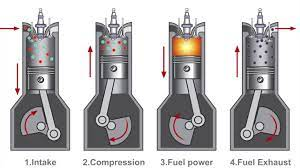

Let’s check out an example app by running the following:

```r
library(shiny)
runExample("01_hello")
```

So let’s break down what we see.

We will start with the ui.

Before we begin let’s copy and paste the code from the running app. Save it as **app.R** so R studio can recognize your code as an app. You can add anything before but it must end with **app.R**. When we do this we will see a new button **Run App** with a play button appear on the top right of our R script. We will also see a blue button appear that would **publish** your application to a RStudio Connect Server. This is how we allow other Pfizer colleagues to access our applications.

## UI

The first thing we see is **fluidPage**. This sets up our ui as a grid with rows and columns. This allows us to move and display things based on x and y by selecting row and column numbers. The apps are set to a 12-wide grid system meaning 1 will be the furthest left and 12 will be the farthest right.

```r
fluidPage(
```

Next we see is **titlePanel**. This one is fairly self explanatory. Adds a title to the app. In this example we call it “Hello Shiny!”.

```r
titlePanel("Hello Shiny!")
```

Now we can set what type of app layout design we want. A popular layout is **sidebarLayout**. This is what creates a simple sidebar on the left or right side of the app(add option **position = “right”**). You can also create a custom layout using **fluidRow** and **column** without setting up a layout and using the grid system. Other options include **tabsetPanel**, which creates an app with tabs and **navlistPanel**, which combines tabs into a sidebar panel layout. The final options is **navbarPage** which is useful for combining multiple tabs that each have their own individual sub-components.

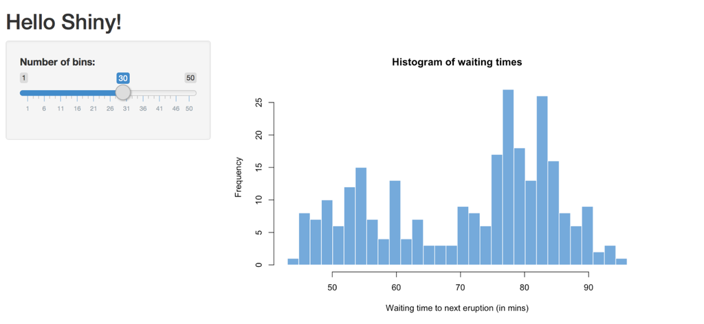

```r
sidebarLayout(
```

Within sidebarLayout we have 2 working areas. **sidebarPanel** and the **mainPanel**. Basically anything enclosed within the sidebarPanel will appear in that area and anything within the mainpanel will be displayed in the respective area.

Under the sidebarPanel we see our first **control widget** of a slider. More control widgets can be seen [here](https://shiny.rstudio.com/tutorial/written-tutorial/lesson3/)

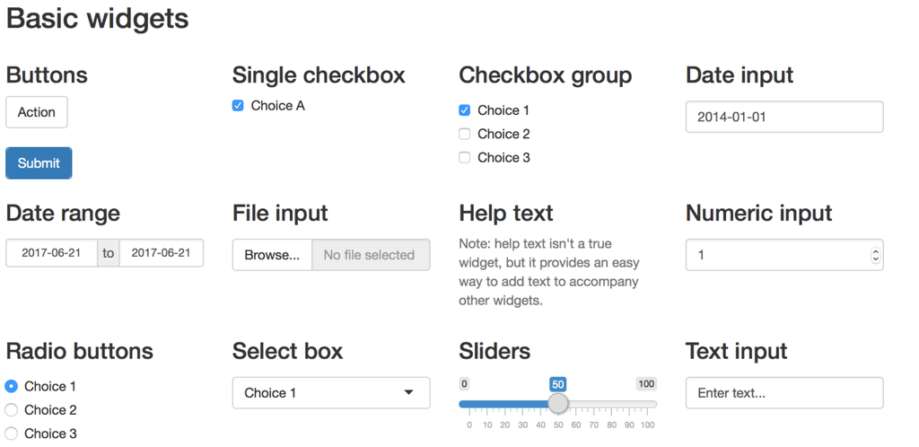

Note: How do you know what widgets are available, how to create them, and their options? Google away!!!

Let’s dive into the slider. You can set up a slider with **sliderInput**.

```r
sliderInput(
```

How can we find out what options are available to us besides google?

Try typing sliderInput into your rscript or console and hitting tab.

**inputId**: allows us to use this as an input for another function. We can call it by using **input$“name of inputId”**.

**label**: title or label of slider

**min**: min value of slider

**max**: max value of slider

**value**: starting (set) value of slider

In our **mainPanel** we see a single histogram that we render using **plotOutput**. Type into your console and check out the options available.

Our **plotOutput** has an **outputId**. As opposed to the inputId this option is looking for an output from another function. We can call it by using the name of the output object we set in the server or other location.

## Server

We set our server function with an input and output. This allows us to input variables **from** our UI and output variables **to** our UI.

We start by creating an output variable. We do this by typing **output$“outputvariablename”**.

Then we tell the server what we want to do with the output. In this case we are using **renderPlot**. We can also **renderPrint**, **renderTable**, and create **reactive** elements that can be used in other functions but do not render anything in the ui (conductors).

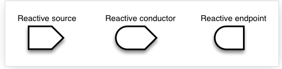

Based off what you have learned so far throughout the coding classes, what is going on within the renderPlot?

Check out faithful dataset and new x variable.

Change input$bins to a value (say 25) and run everthing underneath **renderplot** function.

Why do we use plus 1? Breaks are the cutoff at each bar and not the bar themselves so we need to add 1 more break if we are to get the true value of our slider.

```r
output$distPlot <- renderPlot({

    x    <- faithful$waiting
    bins <- seq(min(x), max(x), length.out = input$bins + 1)

    hist(x, breaks = bins, col = "#75AADB", border = "white",
         xlab = "Waiting time to next eruption (in mins)",
         main = "Histogram of waiting times")

    })
```

This output of **“distPlot”** is fed an input of our slider in the sidebarPanel and outputs the histogram to our mainpanel.

## Exercises

1. Change the title name to “My First App”.
2. Change slider title to “Bin Number”.
3. Set starting slider value at 20.
4. Set max bins to 60.
5. Change histogram border to black.
6. Change bar color to pink.
7. Change y axis label to “Number of Occurences”.

Match below:

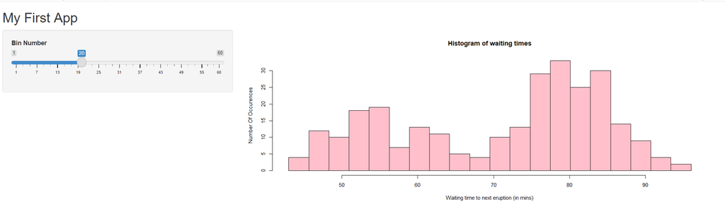

## Sidepanel with Tabs in MainPanel

Let’s try running a more complicated example.

```r
library(shiny)
runExample("06_tabsets")
```

What’s going on at each stage?

What haven’t we seen before?

```r
radioButtons("dist", "Distribution type:",
                  c("Normal" = "norm",
                    "Uniform" = "unif",
                    "Log-normal" = "lnorm",
                    "Exponential" = "exp"))
```

How can you tell what each option is? Practice or always be specific?

inputId

Label

choices as a vector c()

## HTML Content

[HTML options](https://shiny.rstudio.com/tutorial/written-tutorial/lesson2/)

```r
br()
```

**br()** is a line break (blank line)

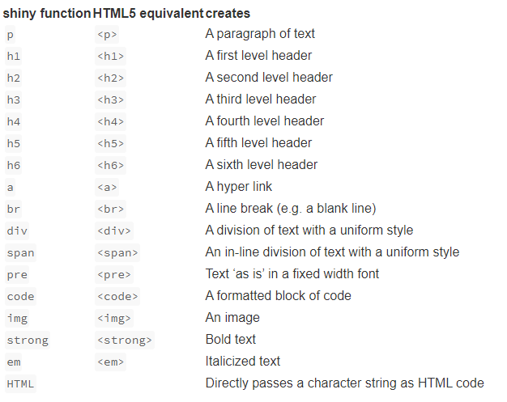

## Tabset panel

This example has tabs within a mainPanel but we could certainly have an app that is soley tabs.

```r
tabsetPanel(type = "tabs",
                  tabPanel("Plot", plotOutput("plot")),
                  tabPanel("Summary", verbatimTextOutput("summary")),
                  tabPanel("Table", tableOutput("table"))
      )
```

**verbatimTextOutput** is the receiver from **renderPrint**.

```r
verbatimTextOutput(
```

**tableOutput** is the receiver from **renderTable**.

```r
tableOutput(
```

Here is our first look at a **reactive** function call.

```r
d <- reactive({
    dist <- switch(input$dist,
                   norm = rnorm,
                   unif = runif,
                   lnorm = rlnorm,
                   exp = rexp,
                   rnorm)

    dist(input$n)
  })
```

We also have our first look at a **switch** which means a different value will be selected based on the selection it correponds to. In this example different distribution types (stats) are run based on the selection on the sidebarPanel. Ex: Normal -> norm -> rnorm

We then run the stats on the input$n (whatever the slider value is). This reactive value is set to d. It needs to be reactive because it appears in multiple functions. d() is now output of stats selected in the sidebarpanel on the value in the slider.

We then move to our output$plot. What do we know? Where is the reactive element and how do we call it “d()”?

What is going on with **paste()**?

[AutoTKR](http://autotkr.pfizer.com/rsconnect/autotkr/autotkr/)

[Pharmapendium Data Explorer (PDE)](http://pde.pfizer.com/rsconnect/pde/pde/)